# Improving Heart Failure Outcomes, BMIN503/EPID600 Project Template

Godefroy Chery, MD, MHS, Danielle L. Mowery, Ph.D., MS, FAMIA

### Overview

For this project, we are seeking to determine the feasibility of using rule logic natural language processing (NLP) to extract the left ventricular ejection fraction (LVEF) from unstructured text data (from medical notes such as discharge summaries). The LVEF is an essential diagnostic component in rendering a heart failure with reduced ejection fraction (HFrEF) diagnosis. It is also used as a prognostic indicator of cardiovascular outcomes and a monitoring tool to assess response to therapeutic interventions. As such, it is an important component of HFrEF management. For our project, we are using the Medical Information Mart for Intensive Care (MIMIC)-III dataset which is a freely-available database comprising deidentified health-related data. Lastly, we will assess how well this NLP logic works by computing its precision, recall and accuracy.

### Introduction

Heart failure is the primary reason for preventable hospital stays in the elderly population in the USA. Unfortunately, it is associated with significant mortality and morbidity with a projected cost of ~70 billion dollars by 2030. While the reason for the associated morbidity and mortality is multifactorial, failure to recognize its onset (underdiagnosis) and failure to adhere to guideline-directed trial-proven medical therapy both play significant contributory roles, further leading to poor cardiovascular outcomes including higher mortality. This is particularly the case for HFrEF which accounts for the majority of heart failure incidence.

Herein, our ultimate goal is to improve on the early recognition of HFrEF and the time to diagnosis of HFrEF by leveraging unstructured and structured data in the electronic health record (EHR). For this course specifically (BMIN503), we are seeking to extract the left ventricular ejection fraction (LVEF) which is a critical diagnostic AND prognostic indicator of heart failure status and cardiovascular outcomes from unstructured data such as free-text clinical notes (e.g., outside hospital discharge summary notes, clinician notes, etc.).

The LVEF is obtained following assessment of the cardiac function with an echocardiogram. While it can be documented in table format in the echocardiogram report, more often than not, it is documented in free-text clinical notes (e.g., clinician notes) or reports. This is particularly true for patients that are coming from other hospitals where it is not feasible to transfer echocardiogram DICOM images to the receiving hospital, further impeding appropriate and timely patient care.

### Methods

For this project, we are using MIMIC-III which is a large, freely-available database comprising deidentified health-related data associated with over forty thousand patients who stayed in critical care units of the Beth Israel Deaconess Medical Center between 2001 and 2012. This is a vast dataset with many variables and limited access. It comes in form of various data tables which were then cleaned. The following steps detail our methods.

Method: Step 1: Getting access to the MIMIC-III dataset which is a large, freely-available database comprising deidentified health-related data associated with over forty thousand patients who stayed in critical care units of the Beth Israel Deaconess Medical Center between 2001 and 2012.

Step 2: Querying and cleaning the data. Merge pertinent datatables together. Provide a descriptive analysis including basic demographics of the MIMIC-III cohort.

Step 3: Defying case and cohort of for the population based on ICD 9 codes. Case definition for heart failure with reduced ejection fraction (HFrEF) was adapted from https://phekb.org/ and modified.

Step 4: Assessing for any significant association between pertinent variables and outcome (heart failure).

Step 5: Querying notes associated with heart failure encoded encounters. Developing and then applying open-source NLP tools to encode and retrieve LVEF.

Step 6: Lastly, we evaluated how well the predictive power of rule logic using accuracy, precision, and recall.

#Retrieving datatables

```r
library(data.table)
library(ggplot2)
library(dplyr)
library(magrittr)
library(pROC)
NOTEEVENTS <- read.csv("~/Downloads/NOTEEVENTS.csv", comment.char="#")
PATIENTS <- read.csv("~/Downloads/PATIENTS.csv")
DIAGNOSES_ICD <- read.csv("~/Downloads/DIAGNOSES_ICD_3.csv", header=TRUE)
ADMISSIONS <- read.csv("~/Downloads/ADMISSIONS.csv", header=TRUE)
```

#Query the data, QI and cleaning

```r
#Queryng the datasets
head(PATIENTS)
```

```
##   ROW_ID SUBJECT_ID GENDER                 DOB                 DOD
## 1    234        249      F 2075-03-13 00:00:00
## 2    235        250      F 2164-12-27 00:00:00 2188-11-22 00:00:00
## 3    236        251      M 2090-03-15 00:00:00
## 4    237        252      M 2078-03-06 00:00:00
## 5    238        253      F 2089-11-26 00:00:00
## 6    239        255      M 2109-08-05 00:00:00
##              DOD_HOSP DOD_SSN EXPIRE_FLAG
## 1                                       0
## 2 2188-11-22 00:00:00                   1
## 3                                       0
## 4                                       0
## 5                                       0
## 6                                       0
```

```r
head(DIAGNOSES_ICD)
```

```
##   ROW_ID SUBJECT_ID HADM_ID SEQ_NUM ICD9_CODE
## 1   1297        109  172335       1     40301
## 2   1298        109  172335       2       486
## 3   1299        109  172335       3     58281
## 4   1300        109  172335       4      5855
## 5   1301        109  172335       5      4254
## 6   1302        109  172335       6      2762
```

```r
head(NOTEEVENTS)
```

```
##   ROW_ID SUBJECT_ID HADM_ID  CHARTDATE CHARTTIME STORETIME          CATEGORY
## 1    174      22532  167853 2151-08-04                     Discharge summary
## 2    175      13702  107527 2118-06-14                     Discharge summary
## 3    176      13702  167118 2119-05-25                     Discharge summary
## 4    177      13702  196489 2124-08-18                     Discharge summary
## 5    178      26880  135453 2162-03-25                     Discharge summary
## 6    179      53181  170490 2172-03-08                     Discharge summary
##   DESCRIPTION CGID ISERROR
## 1      Report   NA      NA
## 2      Report   NA      NA
## 3      Report   NA      NA
## 4      Report   NA      NA
## 5      Report   NA      NA
## 6      Report   NA      NA
##                                                                                                                                                                                                                                                                                                          …
## 1                                                                                                                                                                                                                                                                                                        …
## 2                                                                                                                                                                                                                                                                                                        …
## 3                                                                                                                                                                                                                                                                                                        …
## 4 Admission Date:  [**2124-7-21**]              Discharge Date:   [**2124-8-18**]\n\n\nService: MEDICINE\n\nAllergies:\nAmlodipine\n\nAttending:[**First Name3 (LF) 898**]\nChief Complaint:\nCOPD exacerbation/Shortness of Breath\n\nMajor Surgical or Invasive Procedure:\nIntubation\narterial line p…
## 5                                                                                                                                                                                                                                                                                                        …
## 6                                                                                                                                                                                                                                                                                                        …
```

```r
#Investigating unique subject IDs (patients) in the various data tables
uniquea <-length(unique(ADMISSIONS$SUBJECT_ID)) #46,520 unique subject IDs
uniqued <-length(unique(DIAGNOSES_ICD$SUBJECT_ID)) #46,520 unique subject IDs
uniquep <-length(unique(PATIENTS$SUBJECT_ID)) #46,520 unique subject IDs
uniquens <-length(unique(NOTEEVENTS$SUBJECT_ID)) #46146 unique subject IDs

#Duplicates in subject ID for the Patient datatable.
library(dplyr)
PATIENTS %>%
group_by(SUBJECT_ID) %>%
  filter(n()>1) #There is no duplicate.
```

```
## # A tibble: 0 × 8
## # Groups:   SUBJECT_ID [0]
## # … with 8 variables: ROW_ID <int>, SUBJECT_ID <int>, GENDER <chr>, DOB <chr>,
## #   DOD <chr>, DOD_HOSP <chr>, DOD_SSN <chr>, EXPIRE_FLAG <int>
```

```r
#Let's look at the various types of notes in category column.
unique_c <-unique(NOTEEVENTS$CATEGORY)
uniquend <-unique(NOTEEVENTS$DESCRIPTION)
NoteSum <-sum(NOTEEVENTS$CATEGORY == "Discharge summary")
```

##Results #Creating a basic demographic datasets

```r
library(dplyr)
library(plyr)
```

```r
#Joining data tables PATIENTS with ADMISSIONS which contain demographics including ethnicity, insurance, etc.
Demographic<- dplyr::inner_join(PATIENTS, ADMISSIONS, by = "SUBJECT_ID")
Demographic <-select(Demographic, SUBJECT_ID, GENDER, ADMISSION_TYPE, ETHNICITY, MARITAL_STATUS, INSURANCE)

#Removing duplicate rows by subject_ID. This was done after querying the data to visualize what constitutes duplicated rows and what data is contained within those rows.
Demographic <- Demographic[!duplicated(Demographic$SUBJECT_ID), ]
```

#Creating a basic demographic tables

```r
#Table 1. Basic demographic of the cohort
library (gtsummary)
Demographic  %>% gtsummary::tbl_summary()
```

| **Characteristic** | **N = 46,520**<sup>1</sup> |
| --- | --- |
| SUBJECT_ID | 24,650 (12,287, 55,478) |
| GENDER |  |
| F | 20,399 (44%) |
| M | 26,121 (56%) |
| ADMISSION_TYPE |  |
| ELECTIVE | 6,302 (14%) |
| EMERGENCY | 31,247 (67%) |
| NEWBORN | 7,829 (17%) |
| URGENT | 1,142 (2.5%) |
| ETHNICITY |  |
| AMERICAN INDIAN/ALASKA NATIVE | 45 (<0.1%) |
| AMERICAN INDIAN/ALASKA NATIVE FEDERALLY RECOGNIZED TRIBE | 2 (<0.1%) |
| ASIAN | 1,304 (2.8%) |
| ASIAN - ASIAN INDIAN | 57 (0.1%) |
| ASIAN - CAMBODIAN | 10 (<0.1%) |
| ASIAN - CHINESE | 223 (0.5%) |
| ASIAN - FILIPINO | 15 (<0.1%) |
| ASIAN - JAPANESE | 7 (<0.1%) |
| ASIAN - KOREAN | 11 (<0.1%) |
| ASIAN - OTHER | 15 (<0.1%) |
| ASIAN - THAI | 3 (<0.1%) |
| ASIAN - VIETNAMESE | 41 (<0.1%) |
| BLACK/AFRICAN | 32 (<0.1%) |
| BLACK/AFRICAN AMERICAN | 3,586 (7.7%) |
| BLACK/CAPE VERDEAN | 159 (0.3%) |
| BLACK/HAITIAN | 71 (0.2%) |
| CARIBBEAN ISLAND | 7 (<0.1%) |
| HISPANIC OR LATINO | 1,349 (2.9%) |
| HISPANIC/LATINO - CENTRAL AMERICAN (OTHER) | 9 (<0.1%) |
| HISPANIC/LATINO - COLOMBIAN | 8 (<0.1%) |
| HISPANIC/LATINO - CUBAN | 15 (<0.1%) |
| HISPANIC/LATINO - DOMINICAN | 60 (0.1%) |
| HISPANIC/LATINO - GUATEMALAN | 25 (<0.1%) |
| HISPANIC/LATINO - HONDURAN | 3 (<0.1%) |
| HISPANIC/LATINO - MEXICAN | 11 (<0.1%) |
| HISPANIC/LATINO - PUERTO RICAN | 147 (0.3%) |
| HISPANIC/LATINO - SALVADORAN | 14 (<0.1%) |
| MIDDLE EASTERN | 28 (<0.1%) |
| MULTI RACE ETHNICITY | 111 (0.2%) |
| NATIVE HAWAIIAN OR OTHER PACIFIC ISLANDER | 15 (<0.1%) |
| OTHER | 1,256 (2.7%) |
| PATIENT DECLINED TO ANSWER | 498 (1.1%) |
| PORTUGUESE | 36 (<0.1%) |
| SOUTH AMERICAN | 8 (<0.1%) |
| UNABLE TO OBTAIN | 792 (1.7%) |
| UNKNOWN/NOT SPECIFIED | 4,234 (9.1%) |
| WHITE | 32,074 (69%) |
| WHITE - BRAZILIAN | 42 (<0.1%) |
| WHITE - EASTERN EUROPEAN | 22 (<0.1%) |
| WHITE - OTHER EUROPEAN | 69 (0.1%) |
| WHITE - RUSSIAN | 106 (0.2%) |
| MARITAL_STATUS |  |
|  | 9,780 (21%) |
| DIVORCED | 2,337 (5.0%) |
| LIFE PARTNER | 11 (<0.1%) |
| MARRIED | 18,549 (40%) |
| SEPARATED | 378 (0.8%) |
| SINGLE | 9,740 (21%) |
| UNKNOWN (DEFAULT) | 312 (0.7%) |
| WIDOWED | 5,413 (12%) |
| INSURANCE |  |
| Government | 1,546 (3.3%) |
| Medicaid | 4,424 (9.5%) |
| Medicare | 20,446 (44%) |
| Private | 19,518 (42%) |
| Self Pay | 586 (1.3%) |

<sup>1</sup> Median (IQR); n (%)

```r
#Table 2. Basic demographic of the cohort by gender
Demographic %>% gtsummary::tbl_summary(by = GENDER)
```

| **Characteristic** | **F**, N = 20,399<sup>1</sup> | **M**, N = 26,121<sup>1</sup> |
| --- | --- | --- |
| SUBJECT_ID | 24,613 (12,300, 55,394) | 24,684 (12,279, 55,519) |
| ADMISSION_TYPE |  |  |
| ELECTIVE | 2,554 (13%) | 3,748 (14%) |
| EMERGENCY | 13,731 (67%) | 17,516 (67%) |
| NEWBORN | 3,603 (18%) | 4,226 (16%) |
| URGENT | 511 (2.5%) | 631 (2.4%) |
| ETHNICITY |  |  |
| AMERICAN INDIAN/ALASKA NATIVE | 20 (<0.1%) | 25 (<0.1%) |
| AMERICAN INDIAN/ALASKA NATIVE FEDERALLY RECOGNIZED TRIBE | 1 (<0.1%) | 1 (<0.1%) |
| ASIAN | 572 (2.8%) | 732 (2.8%) |
| ASIAN - ASIAN INDIAN | 20 (<0.1%) | 37 (0.1%) |
| ASIAN - CAMBODIAN | 4 (<0.1%) | 6 (<0.1%) |
| ASIAN - CHINESE | 104 (0.5%) | 119 (0.5%) |
| ASIAN - FILIPINO | 11 (<0.1%) | 4 (<0.1%) |
| ASIAN - JAPANESE | 5 (<0.1%) | 2 (<0.1%) |
| ASIAN - KOREAN | 7 (<0.1%) | 4 (<0.1%) |
| ASIAN - OTHER | 5 (<0.1%) | 10 (<0.1%) |
| ASIAN - THAI | 0 (0%) | 3 (<0.1%) |
| ASIAN - VIETNAMESE | 14 (<0.1%) | 27 (0.1%) |
| BLACK/AFRICAN | 17 (<0.1%) | 15 (<0.1%) |
| BLACK/AFRICAN AMERICAN | 1,915 (9.4%) | 1,671 (6.4%) |
| BLACK/CAPE VERDEAN | 77 (0.4%) | 82 (0.3%) |
| BLACK/HAITIAN | 38 (0.2%) | 33 (0.1%) |
| CARIBBEAN ISLAND | 2 (<0.1%) | 5 (<0.1%) |
| HISPANIC OR LATINO | 536 (2.6%) | 813 (3.1%) |
| HISPANIC/LATINO - CENTRAL AMERICAN (OTHER) | 5 (<0.1%) | 4 (<0.1%) |
| HISPANIC/LATINO - COLOMBIAN | 6 (<0.1%) | 2 (<0.1%) |
| HISPANIC/LATINO - CUBAN | 6 (<0.1%) | 9 (<0.1%) |
| HISPANIC/LATINO - DOMINICAN | 26 (0.1%) | 34 (0.1%) |
| HISPANIC/LATINO - GUATEMALAN | 6 (<0.1%) | 19 (<0.1%) |
| HISPANIC/LATINO - HONDURAN | 1 (<0.1%) | 2 (<0.1%) |
| HISPANIC/LATINO - MEXICAN | 3 (<0.1%) | 8 (<0.1%) |
| HISPANIC/LATINO - PUERTO RICAN | 66 (0.3%) | 81 (0.3%) |
| HISPANIC/LATINO - SALVADORAN | 4 (<0.1%) | 10 (<0.1%) |
| MIDDLE EASTERN | 9 (<0.1%) | 19 (<0.1%) |
| MULTI RACE ETHNICITY | 51 (0.3%) | 60 (0.2%) |
| NATIVE HAWAIIAN OR OTHER PACIFIC ISLANDER | 7 (<0.1%) | 8 (<0.1%) |
| OTHER | 495 (2.4%) | 761 (2.9%) |
| PATIENT DECLINED TO ANSWER | 209 (1.0%) | 289 (1.1%) |
| PORTUGUESE | 16 (<0.1%) | 20 (<0.1%) |
| SOUTH AMERICAN | 4 (<0.1%) | 4 (<0.1%) |
| UNABLE TO OBTAIN | 327 (1.6%) | 465 (1.8%) |
| UNKNOWN/NOT SPECIFIED | 1,740 (8.5%) | 2,494 (9.5%) |
| WHITE | 13,953 (68%) | 18,121 (69%) |
| WHITE - BRAZILIAN | 20 (<0.1%) | 22 (<0.1%) |
| WHITE - EASTERN EUROPEAN | 7 (<0.1%) | 15 (<0.1%) |
| WHITE - OTHER EUROPEAN | 31 (0.2%) | 38 (0.1%) |
| WHITE - RUSSIAN | 59 (0.3%) | 47 (0.2%) |
| MARITAL_STATUS |  |  |
|  | 4,402 (22%) | 5,378 (21%) |
| DIVORCED | 1,220 (6.0%) | 1,117 (4.3%) |
| LIFE PARTNER | 5 (<0.1%) | 6 (<0.1%) |
| MARRIED | 6,218 (30%) | 12,331 (47%) |
| SEPARATED | 213 (1.0%) | 165 (0.6%) |
| SINGLE | 4,146 (20%) | 5,594 (21%) |
| UNKNOWN (DEFAULT) | 156 (0.8%) | 156 (0.6%) |
| WIDOWED | 4,039 (20%) | 1,374 (5.3%) |
| INSURANCE |  |  |
| Government | 626 (3.1%) | 920 (3.5%) |
| Medicaid | 1,918 (9.4%) | 2,506 (9.6%) |
| Medicare | 9,854 (48%) | 10,592 (41%) |
| Private | 7,849 (38%) | 11,669 (45%) |
| Self Pay | 152 (0.7%) | 434 (1.7%) |

<sup>1</sup> Median (IQR); n (%)

```r
#Table 3. Basic demographic of the cohort by insurance status
Demographic %>% gtsummary::tbl_summary(by = INSURANCE)
```

| **Characteristic** | **Government**, N = 1,546<sup>1</sup> | **Medicaid**, N = 4,424<sup>1</sup> | **Medicare**, N = 20,446<sup>1</sup> | **Private**, N = 19,518<sup>1</sup> | **Self Pay**, N = 586<sup>1</sup> |
| --- | --- | --- | --- | --- | --- |
| SUBJECT_ID | 24,512 (11,908, 56,148) | 24,604 (12,250, 54,523) | 28,066 (14,155, 63,177) | 21,712 (10,847, 43,540) | 24,298 (11,511, 55,131) |
| GENDER |  |  |  |  |  |
| F | 626 (40%) | 1,918 (43%) | 9,854 (48%) | 7,849 (40%) | 152 (26%) |
| M | 920 (60%) | 2,506 (57%) | 10,592 (52%) | 11,669 (60%) | 434 (74%) |
| ADMISSION_TYPE |  |  |  |  |  |
| ELECTIVE | 107 (6.9%) | 301 (6.8%) | 3,162 (15%) | 2,717 (14%) | 15 (2.6%) |
| EMERGENCY | 1,027 (66%) | 2,802 (63%) | 16,688 (82%) | 10,203 (52%) | 527 (90%) |
| NEWBORN | 381 (25%) | 1,233 (28%) | 1 (<0.1%) | 6,178 (32%) | 36 (6.1%) |
| URGENT | 31 (2.0%) | 88 (2.0%) | 595 (2.9%) | 420 (2.2%) | 8 (1.4%) |
| ETHNICITY |  |  |  |  |  |
| AMERICAN INDIAN/ALASKA NATIVE | 1 (<0.1%) | 9 (0.2%) | 4 (<0.1%) | 30 (0.2%) | 1 (0.2%) |
| AMERICAN INDIAN/ALASKA NATIVE FEDERALLY RECOGNIZED TRIBE | 0 (0%) | 2 (<0.1%) | 0 (0%) | 0 (0%) | 0 (0%) |
| ASIAN | 62 (4.0%) | 362 (8.2%) | 254 (1.2%) | 617 (3.2%) | 9 (1.5%) |
| ASIAN - ASIAN INDIAN | 5 (0.3%) | 11 (0.2%) | 11 (<0.1%) | 30 (0.2%) | 0 (0%) |
| ASIAN - CAMBODIAN | 0 (0%) | 3 (<0.1%) | 2 (<0.1%) | 5 (<0.1%) | 0 (0%) |
| ASIAN - CHINESE | 16 (1.0%) | 87 (2.0%) | 70 (0.3%) | 50 (0.3%) | 0 (0%) |
| ASIAN - FILIPINO | 1 (<0.1%) | 1 (<0.1%) | 6 (<0.1%) | 7 (<0.1%) | 0 (0%) |
| ASIAN - JAPANESE | 0 (0%) | 1 (<0.1%) | 4 (<0.1%) | 2 (<0.1%) | 0 (0%) |
| ASIAN - KOREAN | 0 (0%) | 2 (<0.1%) | 1 (<0.1%) | 8 (<0.1%) | 0 (0%) |
| ASIAN - OTHER | 1 (<0.1%) | 4 (<0.1%) | 4 (<0.1%) | 6 (<0.1%) | 0 (0%) |
| ASIAN - THAI | 3 (0.2%) | 0 (0%) | 0 (0%) | 0 (0%) | 0 (0%) |
| ASIAN - VIETNAMESE | 2 (0.1%) | 15 (0.3%) | 11 (<0.1%) | 13 (<0.1%) | 0 (0%) |
| BLACK/AFRICAN | 5 (0.3%) | 10 (0.2%) | 9 (<0.1%) | 8 (<0.1%) | 0 (0%) |
| BLACK/AFRICAN AMERICAN | 328 (21%) | 762 (17%) | 1,311 (6.4%) | 1,124 (5.8%) | 61 (10%) |
| BLACK/CAPE VERDEAN | 21 (1.4%) | 48 (1.1%) | 48 (0.2%) | 39 (0.2%) | 3 (0.5%) |
| BLACK/HAITIAN | 5 (0.3%) | 23 (0.5%) | 19 (<0.1%) | 22 (0.1%) | 2 (0.3%) |
| CARIBBEAN ISLAND | 1 (<0.1%) | 1 (<0.1%) | 2 (<0.1%) | 3 (<0.1%) | 0 (0%) |
| HISPANIC OR LATINO | 167 (11%) | 390 (8.8%) | 316 (1.5%) | 428 (2.2%) | 48 (8.2%) |
| HISPANIC/LATINO - CENTRAL AMERICAN (OTHER) | 2 (0.1%) | 0 (0%) | 1 (<0.1%) | 6 (<0.1%) | 0 (0%) |
| HISPANIC/LATINO - COLOMBIAN | 3 (0.2%) | 3 (<0.1%) | 1 (<0.1%) | 1 (<0.1%) | 0 (0%) |
| HISPANIC/LATINO - CUBAN | 0 (0%) | 2 (<0.1%) | 7 (<0.1%) | 5 (<0.1%) | 1 (0.2%) |
| HISPANIC/LATINO - DOMINICAN | 9 (0.6%) | 14 (0.3%) | 20 (<0.1%) | 14 (<0.1%) | 3 (0.5%) |
| HISPANIC/LATINO - GUATEMALAN | 9 (0.6%) | 9 (0.2%) | 4 (<0.1%) | 1 (<0.1%) | 2 (0.3%) |
| HISPANIC/LATINO - HONDURAN | 0 (0%) | 0 (0%) | 2 (<0.1%) | 0 (0%) | 1 (0.2%) |
| HISPANIC/LATINO - MEXICAN | 2 (0.1%) | 3 (<0.1%) | 1 (<0.1%) | 5 (<0.1%) | 0 (0%) |
| HISPANIC/LATINO - PUERTO RICAN | 5 (0.3%) | 50 (1.1%) | 50 (0.2%) | 38 (0.2%) | 4 (0.7%) |
| HISPANIC/LATINO - SALVADORAN | 2 (0.1%) | 8 (0.2%) | 0 (0%) | 3 (<0.1%) | 1 (0.2%) |
| MIDDLE EASTERN | 2 (0.1%) | 6 (0.1%) | 5 (<0.1%) | 15 (<0.1%) | 0 (0%) |
| MULTI RACE ETHNICITY | 10 (0.6%) | 25 (0.6%) | 26 (0.1%) | 44 (0.2%) | 6 (1.0%) |
| NATIVE HAWAIIAN OR OTHER PACIFIC ISLANDER | 0 (0%) | 3 (<0.1%) | 5 (<0.1%) | 6 (<0.1%) | 1 (0.2%) |
| OTHER | 78 (5.0%) | 185 (4.2%) | 338 (1.7%) | 620 (3.2%) | 35 (6.0%) |
| PATIENT DECLINED TO ANSWER | 11 (0.7%) | 32 (0.7%) | 168 (0.8%) | 280 (1.4%) | 7 (1.2%) |
| PORTUGUESE | 3 (0.2%) | 9 (0.2%) | 14 (<0.1%) | 10 (<0.1%) | 0 (0%) |
| SOUTH AMERICAN | 2 (0.1%) | 4 (<0.1%) | 2 (<0.1%) | 0 (0%) | 0 (0%) |
| UNABLE TO OBTAIN | 33 (2.1%) | 64 (1.4%) | 384 (1.9%) | 286 (1.5%) | 25 (4.3%) |
| UNKNOWN/NOT SPECIFIED | 120 (7.8%) | 322 (7.3%) | 2,074 (10%) | 1,622 (8.3%) | 96 (16%) |
| WHITE | 622 (40%) | 1,924 (43%) | 15,146 (74%) | 14,109 (72%) | 273 (47%) |
| WHITE - BRAZILIAN | 14 (0.9%) | 10 (0.2%) | 3 (<0.1%) | 11 (<0.1%) | 4 (0.7%) |
| WHITE - EASTERN EUROPEAN | 0 (0%) | 2 (<0.1%) | 9 (<0.1%) | 11 (<0.1%) | 0 (0%) |
| WHITE - OTHER EUROPEAN | 0 (0%) | 6 (0.1%) | 36 (0.2%) | 26 (0.1%) | 1 (0.2%) |
| WHITE - RUSSIAN | 1 (<0.1%) | 12 (0.3%) | 78 (0.4%) | 13 (<0.1%) | 2 (0.3%) |
| MARITAL_STATUS |  |  |  |  |  |
|  | 398 (26%) | 1,290 (29%) | 1,146 (5.6%) | 6,768 (35%) | 178 (30%) |
| DIVORCED | 82 (5.3%) | 296 (6.7%) | 1,231 (6.0%) | 698 (3.6%) | 30 (5.1%) |
| LIFE PARTNER | 0 (0%) | 1 (<0.1%) | 5 (<0.1%) | 5 (<0.1%) | 0 (0%) |
| MARRIED | 339 (22%) | 735 (17%) | 9,262 (45%) | 8,109 (42%) | 104 (18%) |
| SEPARATED | 12 (0.8%) | 88 (2.0%) | 171 (0.8%) | 102 (0.5%) | 5 (0.9%) |
| SINGLE | 670 (43%) | 1,823 (41%) | 3,624 (18%) | 3,363 (17%) | 260 (44%) |
| UNKNOWN (DEFAULT) | 7 (0.5%) | 35 (0.8%) | 193 (0.9%) | 72 (0.4%) | 5 (0.9%) |
| WIDOWED | 38 (2.5%) | 156 (3.5%) | 4,814 (24%) | 401 (2.1%) | 4 (0.7%) |

<sup>1</sup> Median (IQR); n (%)

#Visualizing our cohort dataset

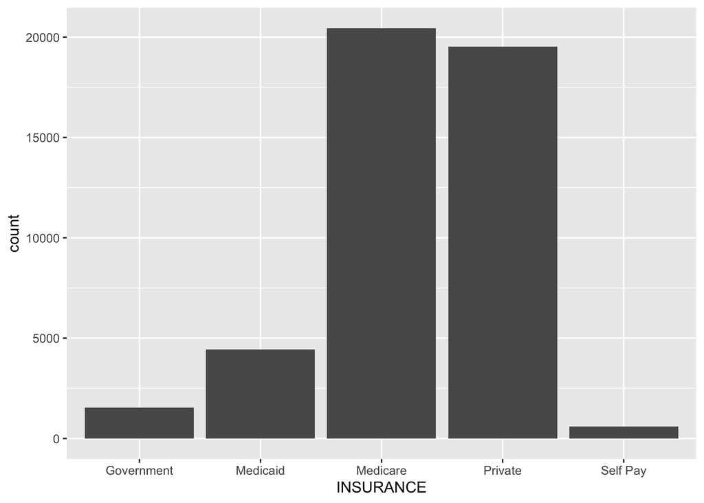

```r
#Visualizing the data
library(ggplot2)

#Figure 1.Visualizing Insurance status in cohort
ggplot(data = Demographic, aes(x = INSURANCE)) +
    geom_bar()
```